# Python Operators

### What are operators in python?

**>>> Operators are the constructs,which can manipulate the value of operands.**

**>>> Consider the expression `4 + 5 = 9`. Here, `4 and 5` are called `operands` and `+` is called the `operator`.**

### Types of Operators:

Python language supports the following types of operators-

> **1. Arithmetic Operators** \ **2. Comparison (Relational) Operators** \ **3. Assignment Operators** \ **4. Logical Operators** \ **5. Bitwise Operators** \ **6. Identity Operators** \ **7. Membership Operators**

### Python Arithmetic Operators

*Arithmetic operators are used to perform mathematical operations like addition, subtraction, multiplication, etc.*

> Let's assume variable **a** holds the value **10** and variable **b** holds the value **21**, then

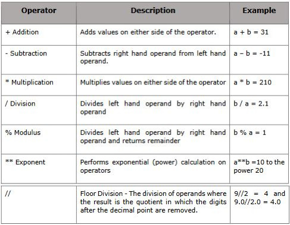

```python
from IPython.display import Image

Image('arthmaticOp.JPG', width = 800, height = 900)
```

**Example 1: Arithmetic operators in Python**

```python
x = 15
y = 4

#Addition
print('x + y =',x+y) # Output: x + y = 19

#Subtraction
print('x - y =',x-y) # Output: x - y = 11

#Multiplication
print('x * y =',x*y) # Output: x * y = 60

#Division
print('x / y =',x/y) # Output: x / y = 3.75

#Exponent
print('x ** y =',x**y, ':(15 to the power of 4)')# Output: x ** y = 50625

#Floor Division
print('x // y =',x//y) # Output: x // y = 3
```

```
x + y = 19
x - y = 11
x * y = 60
x / y = 3.75
x ** y = 50625 :(15 to the power of 4)
x // y = 3
```

### Python Comparison Operators

*These operators compare the values on either side of them and decide the relation among them. They are also called Relational operators.*

> Assume variable **a** holds the value **10** and variable **b** holds the value **20**, then

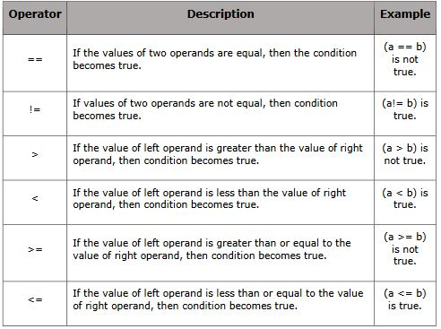

```python
Image('comparisionOp.JPG', width = 800, height = 900)
```

**Example 2: Comparison operators in Python**

```python
x = 10
y = 12

# Output: x > y is False
print('x > y is',x>y)

# Output: x < y is True
print('x < y is',x<y)

# Output: x == y is False
print('x == y is',x==y)

# Output: x != y is True
print('x != y is',x!=y)

# Output: x >= y is False
print('x >= y is',x>=y)

# Output: x <= y is True
print('x <= y is',x<=y)
```

```
x > y is False
x < y is True
x == y is False
x != y is True
x >= y is False
x <= y is True
```

### Python Assignment Operators

*Assignment operators are used in Python to assign values to variables.*

x = 5 is a simple assignment operator that assigns the value 5 on the right to the variable **x** on the left.

> Assume variable **a** holds **10** and variable **b** holds **20**, then-

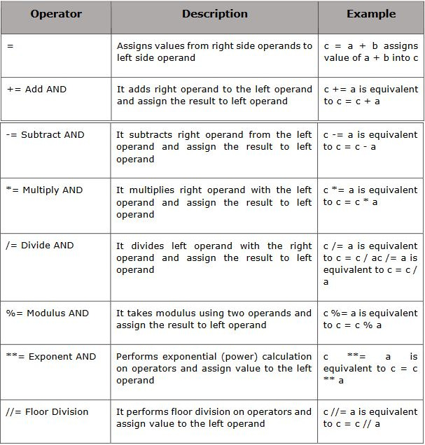

```python
Image('assignmentOp.JPG', width = 800, height = 900)
```

**Example 3: Assignment Operators in Python**

```python
a =21
b =10
c =0

c = a+b # = operator
print("Line 1 - Value of c is ",c)

c += a # += (ADD AND)

print("Line 2 - Value of c is ",c )

c -= a # -= (SUBTRACT AND)
print("Line 3 - Value of c is ",c )

c *= a #*= (Multiplicate AND)
print("Line 4 - Value of c is ", c)
c /=a
print("Line 5 - Value of c is ",c )

c  =2
c %=a
print("Line 6 - Value of c is ",c)

c **=a
print("Line 7 - Value of c is ",c)

c //= a
print("Line 8 - Value of c is ",c)
```

```
Line 1 - Value of c is  31
Line 2 - Value of c is  52
Line 3 - Value of c is  31
Line 4 - Value of c is  651
Line 5 - Value of c is  31.0
Line 6 - Value of c is  2
Line 7 - Value of c is  2097152
Line 8 - Value of c is  99864
```

### Python Logical Operators

*The logical operators are the `and`, `or`, `not` operators.*

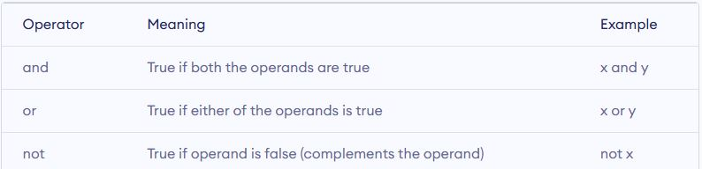

```python
Image('logicalOp.JPG', width = 800, height = 900)
```

**Example 4: Logical Operators in Python**

```python
x = True
y = False

print('x and y is',x and y)

print('x or y is',x or y)

print('not x is',not x)
```

```
x and y is False
x or y is True
not x is False
```

### Python Bitwise Operators

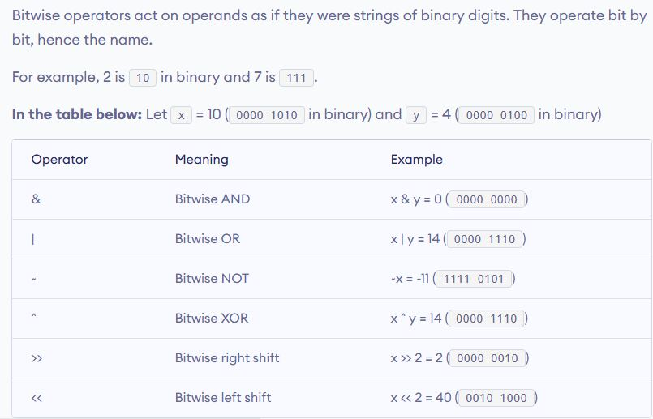

```python
Image('Bitwise.JPG')
```

### Python Identity Operator

`is` and `is not` are the identity operators in Python.

- Identity operators compare the memory locations of two objects.

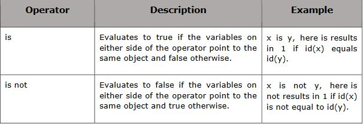

```python
Image('identity.JPG', width = 800, height = 900)
```

**Example 5: Identity operators in Python**

```python
x1 = 5
y1 = 5
x2 = 'Hello'
y2 = 'Hello'
x3 = [1,2,3]
y3 = [1,2,3]

# Output: False
print(x1 is not y1)

# Output: True
print(x2 is y2)

# Output: False
print(x3 is y3)
```

```
False
True
False
```

- Here, we see that `x1` and `y1` are integers of the same values, so they are equal as well as identical. Same is the case with `x2` and `y2` (strings).
- But `x3` and `y3` are lists. They are equal but not identical. It is because the interpreter locates them separately in memory although they are equal.

### Python Membership Operators

*Python’s membership operators test for membership in a sequence, such as strings, lists, or tuples. There are two membership operators `in` and `not in`.*

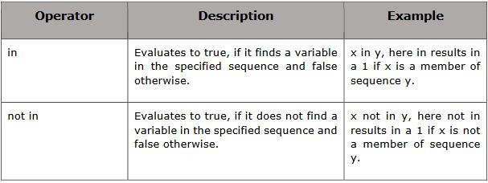

```python
Image('membership.JPG', width = 800, height = 900 )
```

**Example 5: Membership operators in Python**

```python
x = 'Hello world'
y = {1:'a',2:'b'}

# Output: True
print('H' in x)

# Output: True
print('hello' not in x)

# Output: True
print(1 in y)

# Output: False
print('a' in y)
```

```
True
True
True
False
```

## Python Operators Precedence

- The following table lists all the operators from highest precedence to the lowest.

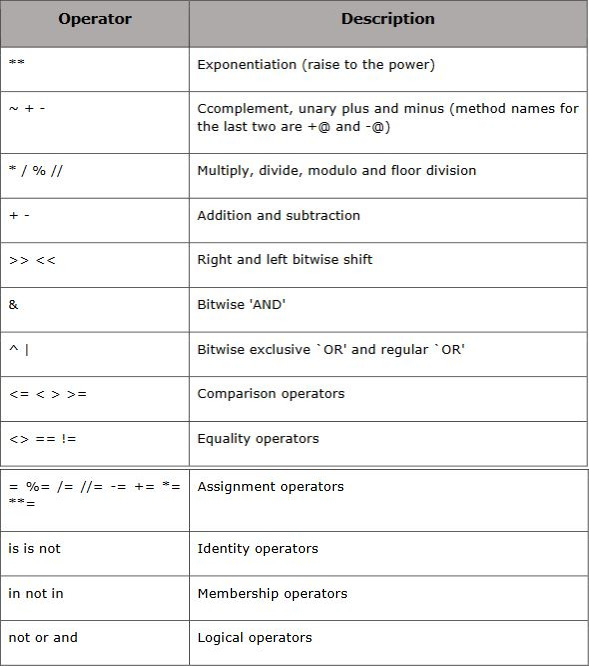

```python
Image('pres.jpg', width = 800, height = 900)
```